# Model Training And Validation

Hakan Egeli

Soumyendu Sarkar

May 8, 2018

### Regression Model Training and Validation

Comparison of linear models using the RMSE and $R^2$ with their respective standard deviations.

```
##                        RMSE   RMSESD   Rsquared  RsquaredSD
## glm w/ intercept   825.0397 59.52325 0.80146394 0.032461358
## glm w/o intercept  825.3626 63.01898 0.80087053 0.028986041
## glm naive         1829.0816 14.55232 0.02298501 0.009956816
```

### Regression Model Tests Accuracy

RMSE, $R^2$ and MAE results using the test dataset.

```
##        RMSE    Rsquared         MAE
## 832.5044900   0.7975892 541.7249760
```

### Classification Model Training and Validation

and we have performed a repeated K-fold cross-validation totaling 10 folds for each model.

```
##            Accuracy  AccuracySD      Kappa    KappaSD
## rf        0.9174541 0.009931367 0.88603586 0.01393034
## multi     0.8601352 0.018481832 0.80560755 0.02546072
## svmPoly   0.8273299 0.028106512 0.76228539 0.03767114
## rpart2    0.8060379 0.018010135 0.72617754 0.02616293
## svmRad    0.7873179 0.034413608 0.71336580 0.04415798
## rpart     0.7847721 0.029567978 0.68988921 0.04628301
## svmLinear 0.6975236 0.029414860 0.58975703 0.04232325
## naive     0.3839309 0.009398724 0.08882696 0.01742648
```

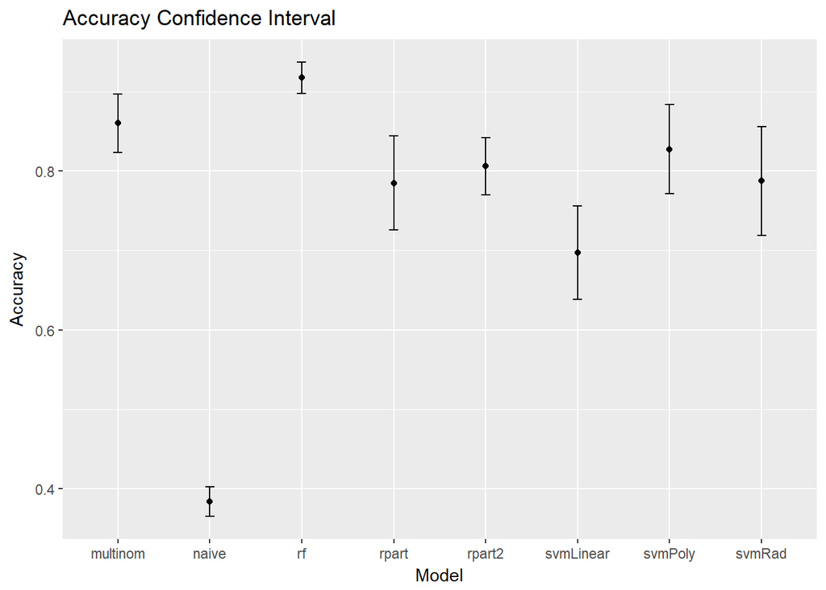

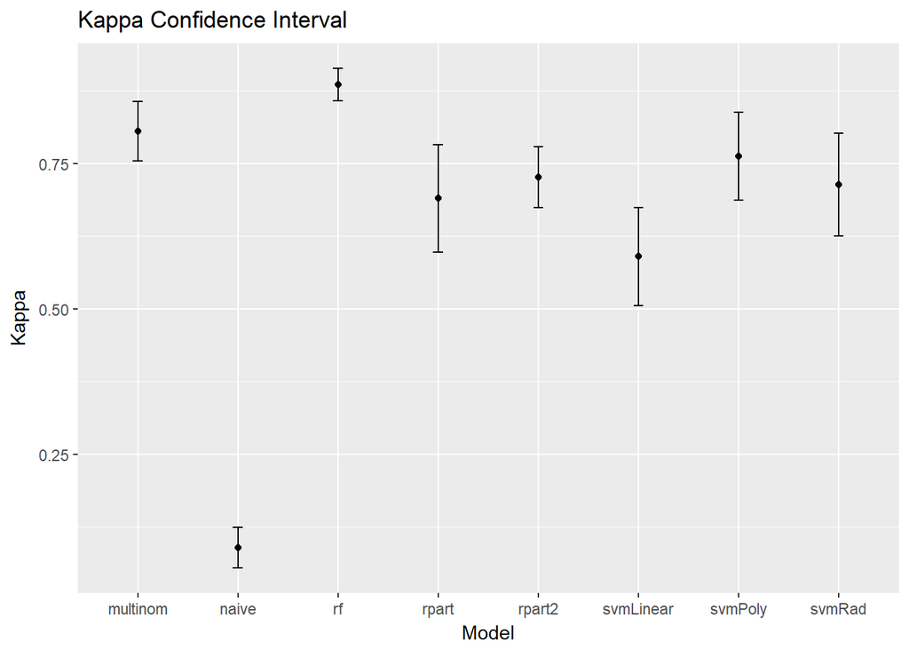

We looked at the Accuracy and Kappa model performance metrics and the confidence interval for each model and determined that the Random Forest model and the Multinomial Regression model were the top two performers. Then, we cheched the performance metics for these two top models against the test dataset that we have set aside (which as not used during the training) to re-evaluate their performance.

### Classification Test Accuracy for the Top Two Models

#### Random Rorest model against the test data:

```
##       Accuracy          Kappa  AccuracyLower  AccuracyUpper   AccuracyNull
##   9.362319e-01   9.119633e-01   9.050434e-01   9.596089e-01   3.652174e-01
## AccuracyPValue  McnemarPValue
##  7.300791e-112            NaN
```

```
##              Sensitivity Specificity Precision    Recall
## Class: X0      1.0000000   1.0000000 1.0000000 1.0000000
## Class: X1000   0.8928571   0.9871245 0.9708738 0.8928571
## Class: X2000   0.6818182   0.9690402 0.6000000 0.6818182
## Class: X3000   0.9500000   0.9824561 0.9193548 0.9500000
## Class: X5000   1.0000000   0.9817352 0.9692308 1.0000000
```

**Confusion Matrix**

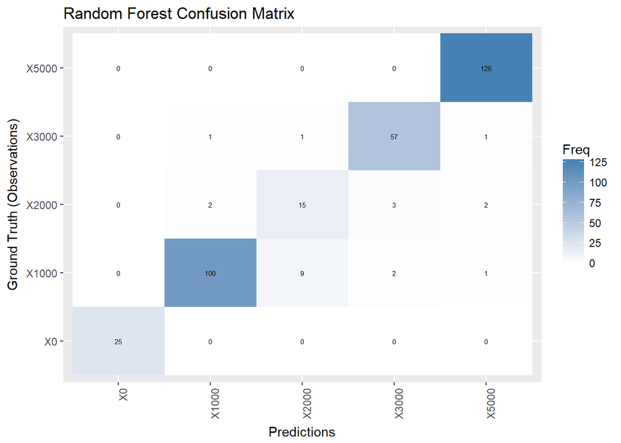

**ROC Curves**

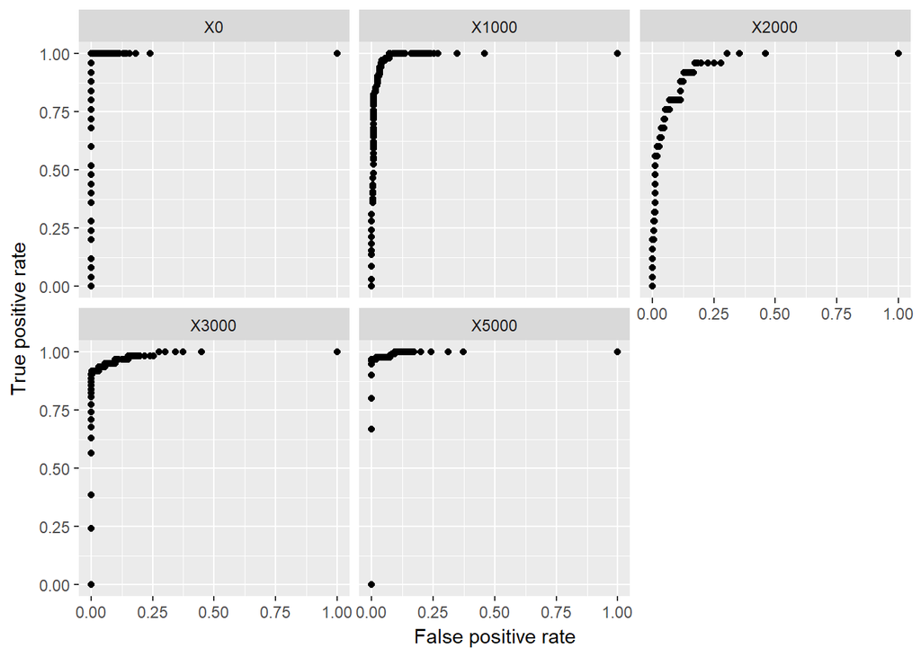

#### Multinomial Regression model against the test data:

```
##       Accuracy          Kappa  AccuracyLower  AccuracyUpper   AccuracyNull
##   8.724638e-01   8.225226e-01   8.325919e-01   9.057813e-01   3.710145e-01
## AccuracyPValue  McnemarPValue
##   3.638268e-83            NaN
```

```
##              Sensitivity Specificity Precision    Recall
## Class: X0      1.0000000   1.0000000 1.0000000 1.0000000
## Class: X1000   0.7983193   0.9646018 0.9223301 0.7983193
## Class: X2000   0.2000000   0.9333333 0.1200000 0.2000000
## Class: X3000   0.8793103   0.9616725 0.8225806 0.8793103
## Class: X5000   0.9921875   0.9861751 0.9769231 0.9921875
```

**Confusion Matrix**

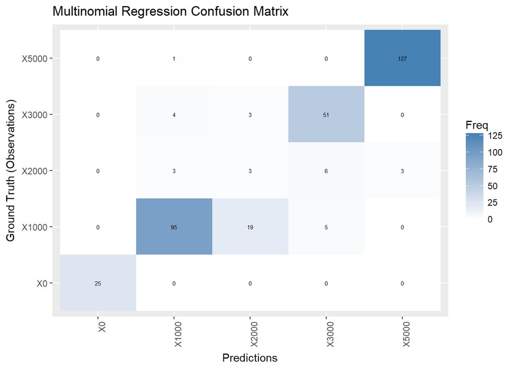

**ROC Curves**

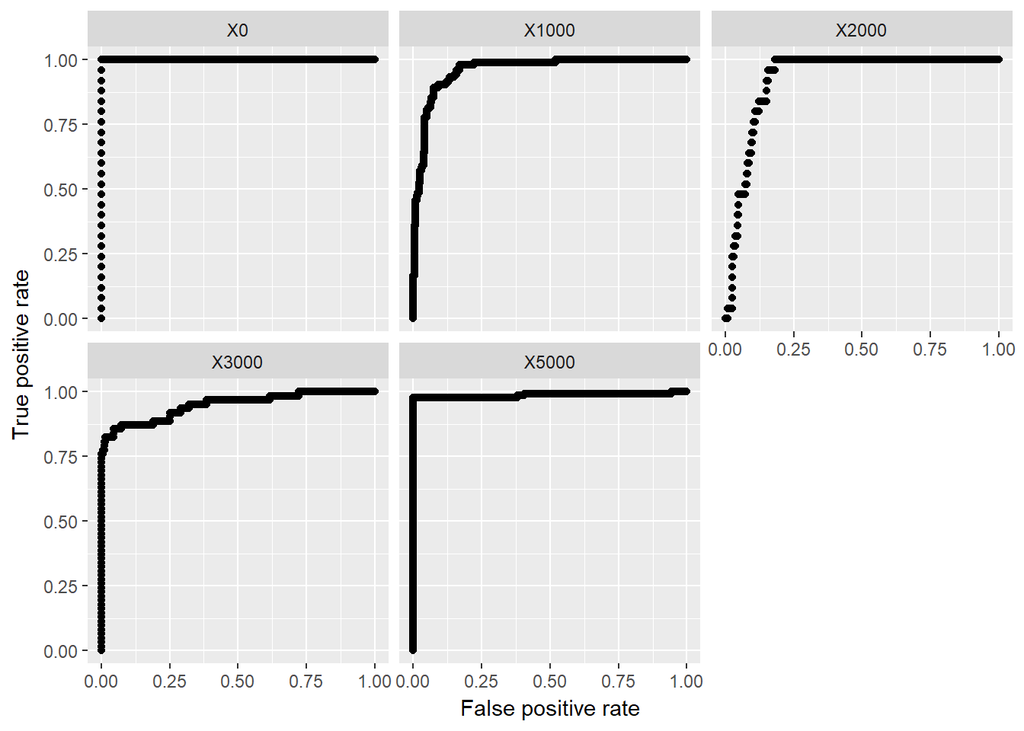

### Final Model

From the last two model tests, we have confirmed that the model built using the random forest was the one with the best accuracy and the best Kappa performance metrics.

We re-trainned the Random Forest model using the entire dataset in order to save this model and package it.

```r
model_rf <- train(CreditLimitCategory ~ JBTRating + CreditLimitLocked + SalesCurrentYr + SalesLastYr + DesignBandSalesLast12Mo + NumberOfStoreLocations + AvgDaysOfPayCategory + ReturnedPaymentCount + RuralUrbanContinuumCode + MetroIndicator + MedianEarnings + MedianIncomeHouseholds - 1, data=dataset, method="rf", metric="Accuracy", trControl=control, tuneGrid=data.frame(.mtry=19))
```

#### Final Accuracy and Kappa values and Standard Deviations

```
##   mtry  Accuracy     Kappa  AccuracySD    KappaSD
## 1   19 0.9229188 0.8935807 0.009840405 0.01352202
```